# GEmpreendimento

Autor: L.Moura, D.Rodrigues

Gestão de Empreendimentos

Aldeia Hoteleira e Turística

#### Breve Descrição do Empreendimento:

O empreendimento consiste na instalação e exploração de uma *aldeia hoteleira e turística*, no concelho de [Porto de Mós](https://pt.wikipedia.org/wiki/Porto_de_Mós), em plena [Serra de Aire e Candeeiros](https://pt.wikipedia.org/wiki/Parque_Natural_das_Serras_de_Aire_e_Candeeiros), perto do percurso pedestre da [Fórnea](http://www.municipio-portodemos.pt/page.aspx?id=218).

A aldeia será composta por um conjunto independente de casas, que têm como característica comum o fato de serem fabricadas a partir de contentores industriais usados. A ideia do tipo de estrutura que se pretende oferecer, pode ser vista ao longo deste trabalho, através das imagens colocadas.

#### Ficheiro CSV

O ficheiro encontra-se guardado no Google Drive, em:  
[Ficheiro de Dados](https://docs.google.com/spreadsheets/d/1z0Gp-dBf3kSwOQhnjDU1GXYW4-oatmm389Z_kasBKTk/edit#gid=0)

### Indíce

- Tabela de Dados com os custos do Empreendimento
- Custo por fases do Empreendimento
- Custo por fases do Tipo de Despesa
- Conclusão

[figure not shown]

### Tabela de Dados - Informação

Para facilitar a análise e a quantificação dos custos do Empreendimento, as despesas foram dividídas em dois grupos:

- Fase
- Tipo

A divisão por fase, tem por objectivo de facilitar a análise progressiva dos custos ao longo do tempo, enquanto a divisão por o tipo de despesa, pretende separar os custos de acordo com a sua natureza.

#### Fase

| Fase | Descrição |
| --- | --- |
| Designe | Fase inicial caracterizada pelo desenvolvimento do Projeto de Empreendimento |
| Construção | Procedente à fase de Designe, sendo caracterizada pela construção do Empreendimento |
| Exploração | Fase do primeiro ano de exploração do Empreendimento |

#### Tipo de Despesa

| Despesa Tipo | Descrição |
| --- | --- |
| Imobiliário | Compra do terreno, contentores e infrastruturas |
| RH | Recursos Humanos. Pessoas a trabalhar diretamente para o Promotor |
| Equipamento | Equipamento de cozinhas, escritório, Paneis solar, etc |
| Serviços | Serviços prestados por pessoas singulares ou empresas |
| Material | Materiais de decoração, limpeza, suporte, etc |

```python
import numpy as np
import pandas as pd
import matplotlib.pyplot as plt

import seaborn as sns
sns.set(style="whitegrid", color_codes=True)
```

```python
%matplotlib inline
```

# Tabela de Dados com a Quantificação dos custos do Empreendimento

Indíce

```python
#leitura de dados da folha do Google para as primeiras 10 linhas
emp=pd.read_csv("https://docs.google.com/spreadsheets/d/1z0Gp-dBf3kSwOQhnjDU1GXYW4-oatmm389Z_kasBKTk/export?format=csv&id")

emp
```

|  | Artigo | Designação dos Trabalhos | Quantidade | Custo Unitário (euros) | Fase | Tipo | Notas |
| --- | --- | --- | --- | --- | --- | --- | --- |
| 0 | 1.1 | Aquisição de Terreno | 1 | 75000 | Designe | Imobiliário | NaN |
| 1 | 1.2 | Preparação do Terreno | 1 | 10000 | Construção | Imobiliário | Limpeza, escavação e aterro |
| 2 | 1.3 | Aquisição Contentores | 10 | 2500 | Construção | Imobiliário | NaN |
| 3 | 1.4 | Saneamento | 1 | 1500 | Construção | Imobiliário | NaN |
| 4 | 1.5 | Água | 1 | 2500 | Construção | Imobiliário | NaN |
| 5 | 1.6 | Electricidade | 1 | 1200 | Construção | Imobiliário | NaN |
| 6 | NaN | NaN | 0 | 0 | NaN | NaN | NaN |
| 7 | 2.1 | Decoração das cabines | 10 | 300 | Construção | Material | NaN |
| 8 | 2.2 | Decoração das cabines | 10 | 100 | Exploração | Material | NaN |
| 9 | 2.3 | Equipamento Cozinha | 10 | 600 | Construção | Equipamento | NaN |
| 10 | 2.4 | Móveis | 10 | 1000 | Construção | Material | NaN |
| 11 | 2.5 | Transf. Cont. em cabines | 10 | 2500 | Construção | Imobiliário | Transformar contentores em cabines |
| 12 | NaN | NaN | 0 | 0 | NaN | NaN | NaN |
| 13 | 3.1 | Gestor de Projeto | 8 | 2310 | Designe | RH | ordenado mensal |
| 14 | 3.2 | Gestor de Projeto | 6 | 2310 | Construção | RH | ordenado mensal |
| 15 | 3.3 | Gestor de Projeto | 12 | 2310 | Exploração | RH | ordenado mensal |
| 16 | 3.4 | Arquiteto | 1 | 3550 | Designe | Serviços | Único pagamento |
| 17 | 3.5 | Arquiteto | 6 | 250 | Construção | Serviços | visita/mensal |

```python
# criar categorias para a tabela de forma a simplificar a análise
emp["Fase"] = emp["Fase"].astype("category")
emp["Fase"].cat.set_categories(["Designe","Construção",
                                "Exploração"],inplace=True)
emp["Tipo"] = emp["Tipo"].astype("category")
emp["Tipo"].cat.set_categories(["Imobiliário","RH","Equipamento",
                                "Material", "Serviços"]
                               ,inplace=True)
# criar nova coluna com o preço total para cada um dos artigos do trabalho
emp["Total (euros)"]=emp["Custo Unitário (euros)"]*emp["Quantidade"]

# remover as colunas que não são precisas para a análise
del emp["Artigo"]
del emp["Notas"]

# passar data to csv file
emp.to_csv("csv/emp.csv")
```

[figure not shown]

Fases do Empreendimento

# Custo por fases do Empreendimento

Indíce

- Fase de Designe
- Fase de Construção
- Fase de Emploração

Para as diversas fases, e de forma a facilitar a análise, e controle de custos ao longo do Projeto, é calculado o custo de cada uma. Em seguinda é apresentado o custo de cada uma das fases, sendo depois feita uma análise, para cada uma das secções, dos valores obtidos.

**Resultados das Despesas quando analisado por fases:**

```python
fase_custo=emp.groupby("Fase")["Total (euros)"].sum()

# passar data to csv file
fase_custo.to_csv("csv/fase_custo.csv")

fase_custo
```

```
Fase
Designe       97030
Construção    99560
Exploração    28720
Name: Total (euros), dtype: int64
```

```
'images/A.png'
```

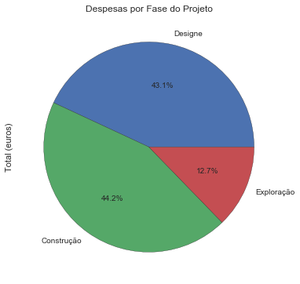

```python
fase_custo.plot(kind="pie", figsize=(6,6), autopct='%1.1f%%', shadow=False, title="Despesas por Fase do Projeto")
plt.savefig("images/A.png")
"images/A.png"
```

Indíce

### Custo em Fase de Designe:

```python
# Custo em fase de Designe
designe_custo=emp.query('Fase==["Designe"]')
designe_custo.sort_values(['Total (euros)'], ascending=False).head()
```

|  | Designação dos Trabalhos | Quantidade | Custo Unitário (euros) | Fase | Tipo | Total (euros) |
| --- | --- | --- | --- | --- | --- | --- |
| 0 | Aquisição de Terreno | 1 | 75000 | Designe | Imobiliário | 75000 |
| 13 | Gestor de Projeto | 8 | 2310 | Designe | RH | 18480 |
| 16 | Arquiteto | 1 | 3550 | Designe | Serviços | 3550 |

#### Custo Total em fase de Designe:

Valor para o custo total dos vários artigos do empreendimento em fase de Designe.

```python
# Soma da coluna dos custos totais para a fase de Construção:
designe_custo["Total (euros)"].sum()
```

```
97030
```

```
'images/B.png'
```

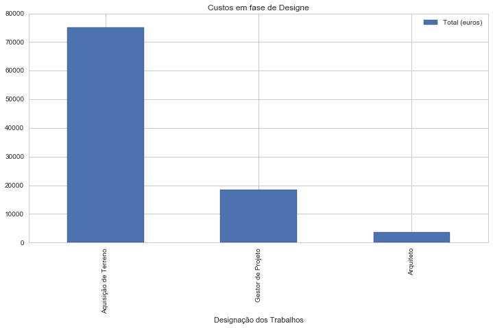

```python
designe_custo.plot(kind="bar", x="Designação dos Trabalhos", y="Total (euros)", grid=True,
                   title="Custos em fase de Designe", figsize=(12,6))
plt.savefig("images/B.png")
"images/B.png"
```

Indíce

### Custo em Fase de Construção:

Tabela apresenta os custos em fase de construção, de forma descendente, sendo apresentado os 5 valores mais altos.

```python
# Custo em fase de Construção
construcao_custo=emp.query('Fase==["Construção"]')
construcao_custo.sort_values(['Total (euros)'], ascending=False).head()
```

|  | Designação dos Trabalhos | Quantidade | Custo Unitário (euros) | Fase | Tipo | Total (euros) |
| --- | --- | --- | --- | --- | --- | --- |
| 2 | Aquisição Contentores | 10 | 2500 | Construção | Imobiliário | 25000 |
| 11 | Transf. Cont. em cabines | 10 | 2500 | Construção | Imobiliário | 25000 |
| 14 | Gestor de Projeto | 6 | 2310 | Construção | RH | 13860 |
| 1 | Preparação do Terreno | 1 | 10000 | Construção | Imobiliário | 10000 |
| 10 | Móveis | 10 | 1000 | Construção | Material | 10000 |

#### Custo Total em fase de Construção:

Valor para o custo total dos vários artigos do empreendimento em fase de Construção.

```python
# Soma da coluna dos custos totais para a fase de Construção:
construcao_custo["Total (euros)"].sum()
```

```
99560
```

```
'images/C.png'
```

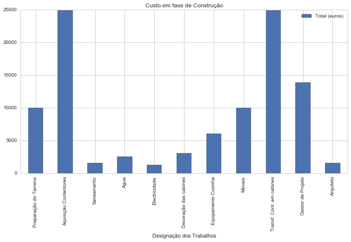

```python
construcao_custo.plot(kind="bar", x="Designação dos Trabalhos", y="Total (euros)",
                      grid=True,title="Custo em fase de Construção",
                     figsize=(12,6))
plt.savefig("images/C.png")
"images/C.png"
```

Indíce

### Custo em Fase de Exploração:

Tabela apresenta os custos em fase de exploração, de forma descendente, sendo apresentado os 5 valores mais altos.

```python
# Custo em fase de Exploração
explora_custo=emp.query('Fase==["Exploração"]')
explora_custo.sort_values(['Total (euros)'], ascending=False).head()
```

|  | Designação dos Trabalhos | Quantidade | Custo Unitário (euros) | Fase | Tipo | Total (euros) |
| --- | --- | --- | --- | --- | --- | --- |
| 15 | Gestor de Projeto | 12 | 2310 | Exploração | RH | 27720 |
| 8 | Decoração das cabines | 10 | 100 | Exploração | Material | 1000 |

#### Custo Total em fase de Exploração:

Valor para o custo total dos vários artigos do empreendimento em fase de Exploração. Valor apresentado é representativo do primeiro ano e servirá de base de para futuras projeções económicas.  
Custo (em euros) em fase de exploração:

```python
# Soma da coluna dos custos totais para a fase de Construção:
explora_custo["Total (euros)"].sum()
```

```
28720
```

```
'images/D.png'
```

[figure not shown]

```python
explora_custo.plot(kind="bar", x="Designação dos Trabalhos", y="Total (euros)",
                      grid=True,title="Custo em fase de Construção",
                      figsize=(12,6))
plt.legend(loc='upper left', shadow=False, fontsize='medium')
plt.savefig("images/D.png")
"images/D.png"
```

[figure not shown]

Tipo de Despesa

Indíce

# Custo por Tipo de Despesa

- Imobiliário
- RH
- Equipamento
- Material
- Serviços

Para as diversos tipos de despesa, e de forma a facilitar a análise e controle de custos ao longo do Projeto, é calculado o custo de cada um dos tipos. Em seguinda é apresentado o custo de cada um dos tipos, sendo depois feita uma análise, para cada uma das secções, dos valores obtidos.

**Resultados das Despesas quando analisado por tipo:**

```python
tipo_custo=emp.groupby("Tipo")["Total (euros)"].sum()
# passar data to csv file
tipo_custo.to_csv("csv/tipo_custo.csv")

tipo_custo
```

```
Tipo
Imobiliário    140200
RH              60060
Equipamento      6000
Material        14000
Serviços         5050
Name: Total (euros), dtype: int64
```

```
'images/E.png'
```

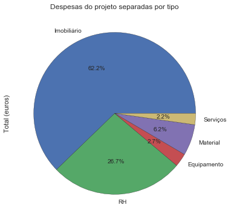

```python
tipo_custo.plot(kind="pie", figsize=(6,6), autopct='%1.1f%%',
                shadow=False, title="Despesas do projeto separadas por tipo")
plt.savefig("images/E.png")
"images/E.png"
```

Indíce

### Imobiliário:

O imobiliário é a primeira parcela e das maiores, a integrarem o Empreendimento.

```python
# Custo do Imobiliário
imob_custo=emp.query('Tipo==["Imobiliário"]')
imob_custo.sort_values(['Total (euros)'], ascending=False).head()
```

|  | Designação dos Trabalhos | Quantidade | Custo Unitário (euros) | Fase | Tipo | Total (euros) |
| --- | --- | --- | --- | --- | --- | --- |
| 0 | Aquisição de Terreno | 1 | 75000 | Designe | Imobiliário | 75000 |
| 2 | Aquisição Contentores | 10 | 2500 | Construção | Imobiliário | 25000 |
| 11 | Transf. Cont. em cabines | 10 | 2500 | Construção | Imobiliário | 25000 |
| 1 | Preparação do Terreno | 1 | 10000 | Construção | Imobiliário | 10000 |
| 4 | Água | 1 | 2500 | Construção | Imobiliário | 2500 |

#### Custo Total do Imobiliário

Valor para o custo total - Equipamento, serviços, materiais, etc - para a compra e preparação do terreno.

```python
# Soma da coluna dos custos totais para Imobiliário:
imob_custo["Total (euros)"].sum()
```

```
140200
```

```
'images/F.png'
```

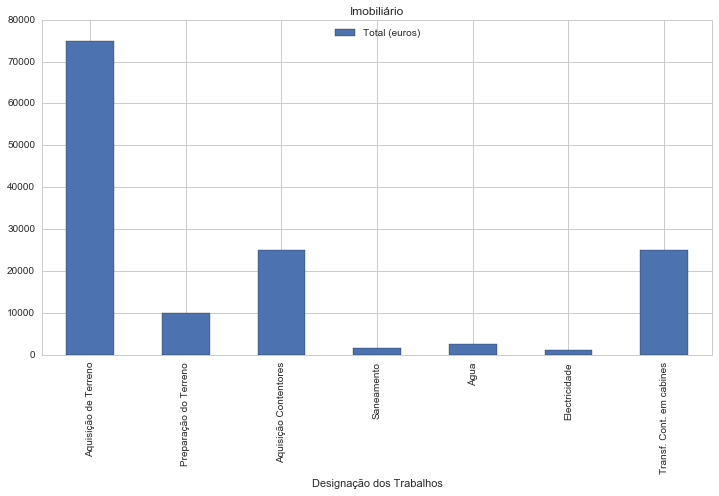

```python
imob_custo.plot(kind="bar", x="Designação dos Trabalhos", y="Total (euros)",
                      grid=True,title="Imobiliário",
                      figsize=(12,6))
plt.legend(loc='upper center', shadow=False, fontsize='medium')
plt.savefig("images/F.png")
"images/F.png"
```

Indíce

### Recursos Humanos:

```python
# Custo Recursos Humanos
rh_custo=emp.query('Tipo==["RH"]')
rh_custo.sort_values(['Total (euros)'], ascending=False).head()
```

|  | Designação dos Trabalhos | Quantidade | Custo Unitário (euros) | Fase | Tipo | Total (euros) |
| --- | --- | --- | --- | --- | --- | --- |
| 15 | Gestor de Projeto | 12 | 2310 | Exploração | RH | 27720 |
| 13 | Gestor de Projeto | 8 | 2310 | Designe | RH | 18480 |
| 14 | Gestor de Projeto | 6 | 2310 | Construção | RH | 13860 |

#### Custo Recursos Humanos

Estimativa de custo para Recursos Humanos.

```python
# Soma da coluna dos custos totais para Recursos Humanos:
rh_custo["Total (euros)"].sum()
```

```
60060
```

```
'images/G.png'
```

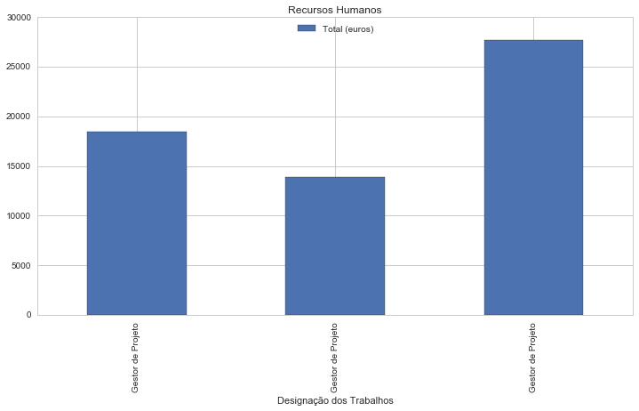

```python
rh_custo.plot(kind="bar", x="Designação dos Trabalhos", y="Total (euros)",
                      grid=True,title="Recursos Humanos",
                      figsize=(12,6))
plt.legend(loc='upper center', shadow=False, fontsize='medium')
plt.savefig("images/G.png")
"images/G.png"
```

Indíce

### Equipamento:

```python
# Custo Equipamento
equip_custo=emp.query('Tipo==["Equipamento"]')
equip_custo.sort_values(['Total (euros)'], ascending=False).head()
```

|  | Designação dos Trabalhos | Quantidade | Custo Unitário (euros) | Fase | Tipo | Total (euros) |
| --- | --- | --- | --- | --- | --- | --- |
| 9 | Equipamento Cozinha | 10 | 600 | Construção | Equipamento | 6000 |

#### Custo Equipamento

Estimativa de custo para Equipamentos.

```python
# Soma da coluna dos custos totais para Recursos Humanos:
equip_custo["Total (euros)"].sum()
```

```
6000
```

```
'images/H.png'
```

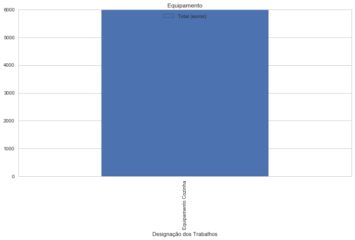

```python
equip_custo.plot(kind="bar", x="Designação dos Trabalhos", y="Total (euros)",
                      grid=True,title="Equipamento",
                      figsize=(12,6))
plt.legend(loc='upper center', shadow=False, fontsize='medium')
plt.savefig("images/H.png")
"images/H.png"
```

Indíce

### Material:

```python
# Custo Material
mat_custo=emp.query('Tipo==["Material"]')
mat_custo.sort_values(['Total (euros)'], ascending=False).head()
```

|  | Designação dos Trabalhos | Quantidade | Custo Unitário (euros) | Fase | Tipo | Total (euros) |
| --- | --- | --- | --- | --- | --- | --- |
| 10 | Móveis | 10 | 1000 | Construção | Material | 10000 |
| 7 | Decoração das cabines | 10 | 300 | Construção | Material | 3000 |
| 8 | Decoração das cabines | 10 | 100 | Exploração | Material | 1000 |

#### Custo Material

Estimativa de custo para Materiais.

```python
# Soma da coluna dos custos totais para Materiais:
mat_custo["Total (euros)"].sum()
```

```
14000
```

```
'images/I.png'
```

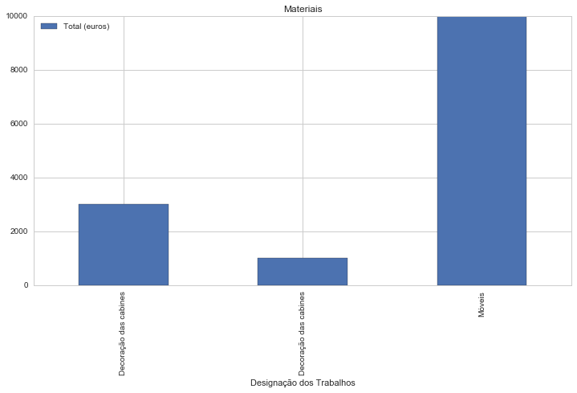

```python
mat_custo.plot(kind="bar", x="Designação dos Trabalhos", y="Total (euros)",
                      grid=True,title="Materiais",
                      figsize=(12,6))
plt.legend(loc='upper left', shadow=False, fontsize='medium')
plt.savefig("images/I.png")
"images/I.png"
```

Indíce

### Serviços:

```python
# Custo Serviços
serv_custo=emp.query('Tipo==["Serviços"]')
serv_custo.sort_values(['Total (euros)'], ascending=False).head()
```

|  | Designação dos Trabalhos | Quantidade | Custo Unitário (euros) | Fase | Tipo | Total (euros) |
| --- | --- | --- | --- | --- | --- | --- |
| 16 | Arquiteto | 1 | 3550 | Designe | Serviços | 3550 |
| 17 | Arquiteto | 6 | 250 | Construção | Serviços | 1500 |

#### Custo dos Serviços

Estimativa de custo para Serviços.

```python
# Soma da coluna dos custos totais para serviços:
serv_custo["Total (euros)"].sum()
```

```
5050
```

```
'images/J.png'
```

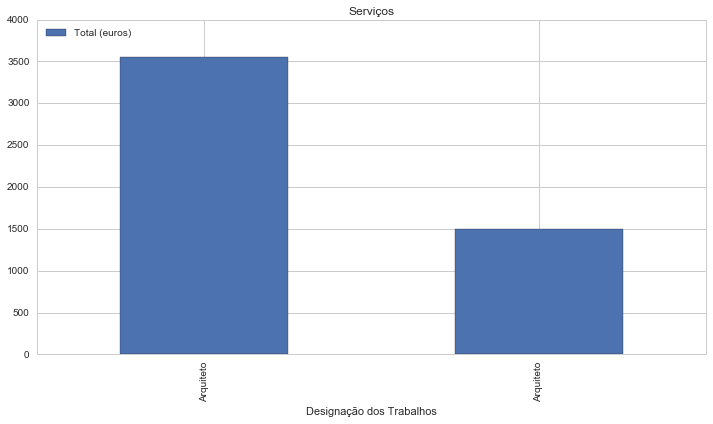

```python
serv_custo.plot(kind="bar", x="Designação dos Trabalhos", y="Total (euros)",
                      grid=True,title="Serviços",
                      figsize=(12,6))
plt.legend(loc='upper left', shadow=False, fontsize='medium')
plt.savefig("images/J.png")
"images/J.png"
```

[figure not shown]

Conclusão

Indíce

# Conclusão

```python
# Preparar totais
dd=designe_custo["Total (euros)"].sum()
cc=construcao_custo["Total (euros)"].sum()
ee=explora_custo["Total (euros)"].sum()
ii=imob_custo["Total (euros)"].sum()
eee=equip_custo["Total (euros)"].sum()
rr=rh_custo["Total (euros)"].sum()
mm=mat_custo["Total (euros)"].sum()
ss=serv_custo["Total (euros)"].sum()
P_total_E=dd+cc+ee

# Preparação do texto
print("Breve resumo dos resultados obtidos: ")
print ("O custo em fase de Designe é de",dd,"euros, em Fase de Construção é de",
       cc,"euros, e de", ee,"euros em Exploração.")
print("Quando analisado em termos do tipos de despesas, foram obtidas as  quantias")
print("de", ii,"euros para Imobiliário,",eee, "euros para Equipamento,",
      rr,"euros para Recursos Humanos",mm )
print("para materiais, e de",ss, "euros para Serviços."   )
print("")
print("O Preço Total do Empreendimento até ao final do primeiro ano de Exploração é de",
      P_total_E, "euros.")
```

```
Breve resumo dos resultados obtidos:
O custo em fase de Designe é de 97030 euros, em Fase de Construção é de 99560 euros, e de 28720 euros em Exploração.
Quando analisado em termos do tipos de despesas, foram obtidas as  quantias
de 140200 euros para Imobiliário, 6000 euros para Equipamento, 60060 euros para Recursos Humanos 14000
para materiais, e de 5050 euros para Serviços.

O Preço Total do Empreendimento até ao final do primeiro ano de Exploração é de 225310 euros.
```

```
'images/graph2.png'
```

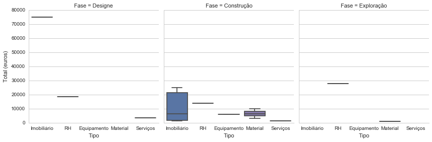

```python
sns.factorplot(x="Tipo", y="Total (euros)",
               col="Fase", data=emp, kind="box");
plt.figure(figsize = (12, 6))
plt.savefig('images/graph2.png')
'images/graph2.png'
```